[figure not shown]

# GET00203 - Estatística Computacional 1

Aula 02 - Geração de amostras aleatórias e cálculo das medidas de resumo

[Rafael Erbisti](https://sites.google.com/site/rerbisti)

## Criando funções

Para criar uma função é importante definir suas entradas (argumentos) e saídas.

Os argumentos devem estar entre parênteses e os comandos da função devem estar entre chaves. Veja o exemplo genérico abaixo.

```r
nome.da.funcao = function(argumento1, ... , argumentoN){
            tarefa1
            tarefa2
            tarefa3
            }
```

Para chamar a função basta digitar seu nome seguido de seus argumentos entre parênteses.

```r
nome.da.funcao(argumento1, ... , argumentoN)
```

Por exemplo, deseja-se criar uma função que calcula o fatorial de um número:

```r
funcao.fatorial = function(n){
  if(n == 0){resultado = 1}else{
  if(n > 0){
    aux = 1
    for (i in 1:n){
      aux = aux*i}
    resultado = aux}
  else{
    resultado = "Não é possível calcular!"}
  }
  return(resultado)}
```

Assim, tem-se

```r
# 0!
funcao.fatorial(0)
```

```
[1] 1
```

```r
# 1!
funcao.fatorial(1)
```

```
[1] 1
```

```r
# 4!
funcao.fatorial(4)
```

```
[1] 24
```

```r
# 5!
funcao.fatorial(5)
```

```
[1] 120
```

Considere que agora deseja-se criar uma função que calcula o valor da função $f(z) = 3 e^{-3z}$, $z \geq 0$ e, em seguida, construir um gráfico dessa função no intervalo $[0,3]$. Assim, tem-se

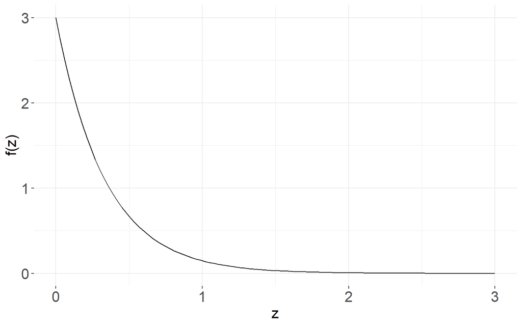

```r
# Construindo a função
f = function(z){
  if_else(z>=0, 3*exp(-3*z), 0)
}

# Construindo o gráfico
ggplot(data = tibble(z = c(0,3)), mapping = aes(x = z)) +
  stat_function(fun = f) +
  labs(y = "f(z)", x = "z") +
  theme_bw() +
  theme(axis.text.x = element_text(size = 16),
        axis.title.x = element_text(size = 16),
        axis.text.y = element_text(size = 16),
        axis.title.y = element_text(size = 16),
        panel.border = element_blank())
```

> **Atividade:** Crie uma função que calcula o valor da função $f(x) = e^{-(x-10)^2}$, $x \in \Re$. Faça um gráfico da função.

## Geração de amostras aleatórias

Para cada distribuição há 4 operações básicas indicadas pelas letras:

- **d** - calcula a função densidade de probabilidade de $f(x)$ no ponto (ou a função de probabilidade no caso discreto).
- **p** - calcula a função de distribuição acumulada $F(x)$ no ponto.
- **q** - calcula o quantil correspondente a uma dada probabilidade.
- **r** - sorteia uma amostra da distribuição.

#### Distribuição Binomial

Seja $X$ a variável aleatória com distribuição $Binomial(n,p)$, ou seja, tem-se que $X \sim Binomial(n,p)$. Nos exemplos abaixo, considere $X \sim Binomial(20, 0.8)$:

```r
# Calculando P(X=15)
dbinom(15, size = 20, prob = 0.8)
```

```
[1] 0.1745595
```

```r
# Calculando P(X<14)
pbinom(13, size = 20, prob = 0.8)
```

```
[1] 0.08669251
```

```r
# Calculando P(X>=14)
1-pbinom(13, size = 20, prob = 0.8)
```

```
[1] 0.9133075
```

```r
# Calculando P(15<X<18)
pbinom(17, size = 20, prob = 0.8) - pbinom(15, size = 20, prob = 0.8)
```

```
[1] 0.4235635
```

```r
# Calculando o 3º decil
qbinom(0.3, size = 20, prob = 0.8)
```

```
[1] 15
```

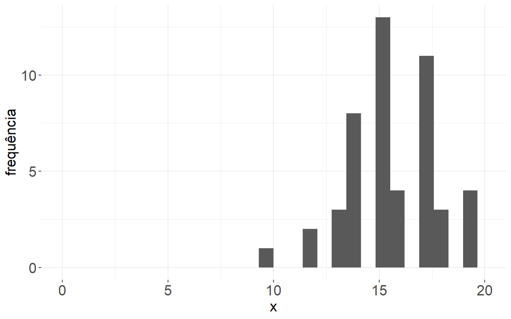

```r
# Gerando uma amostra de tamanho 50 e plotando os dados gerados
amostra.b = rbinom(50, size = 20, prob = 0.8)

ggplot(mapping = aes(x = amostra.b)) +
  geom_histogram() +
  labs(y = "frequência", x = "x") +
  xlim(0,20) +
  theme_bw() +
  theme(axis.text.x = element_text(size = 16),
        axis.title.x = element_text(size = 16),
        axis.text.y = element_text(size = 16),
        axis.title.y = element_text(size = 16),
        panel.border = element_blank())
```

Observe que $E(X)=np$. Neste caso, tem-se que $E(X) = 20 \times 0.8 = 16$. Claramente, ao gerar uma amostra dessa distribuição, espera-se que os dados estejam em torno da média. Incluindo uma reta vertical das médias teórica e empírica na figura acima, tem-se

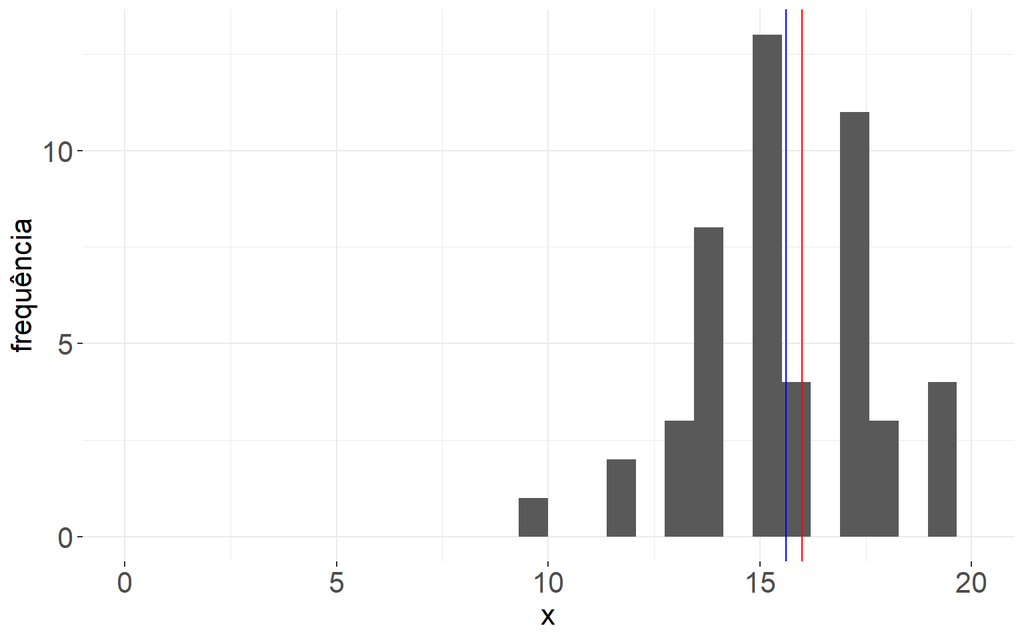

```r
ggplot(mapping = aes(x = amostra.b)) +
  geom_histogram() +
  geom_vline(xintercept = 16, col = "red") +
  geom_vline(xintercept = mean(amostra.b), col = "blue") +
  labs(y = "frequência", x = "x") +
  xlim(0,20) +
  theme_bw() +
  theme(axis.text.x = element_text(size = 16),
        axis.title.x = element_text(size = 16),
        axis.text.y = element_text(size = 16),
        axis.title.y = element_text(size = 16),
        panel.border = element_blank())
```

#### Distribuição Poisson

Seja $Z$ a variável aleatória com distribuição $Poisson(\lambda)$, ou seja, tem-se que $Z \sim Poisson(\lambda)$. Nos exemplos abaixo, considere $Z \sim Poisson(5)$:

```r
# Calculando P(Z=8)
dpois(8, lambda = 5)
```

```
[1] 0.06527804
```

```r
# Calculando P(Z<2)
ppois(1, lambda = 5)
```

```
[1] 0.04042768
```

```r
# Calculando P(Z>=3)
1-ppois(2, lambda = 5)
```

```
[1] 0.875348
```

```r
# Calculando P(1<Z<6)
ppois(5, lambda = 5) - ppois(1, lambda = 5)
```

```
[1] 0.575533
```

```r
# Calculando a mediana
qpois(0.5, lambda = 5)
```

```
[1] 5
```

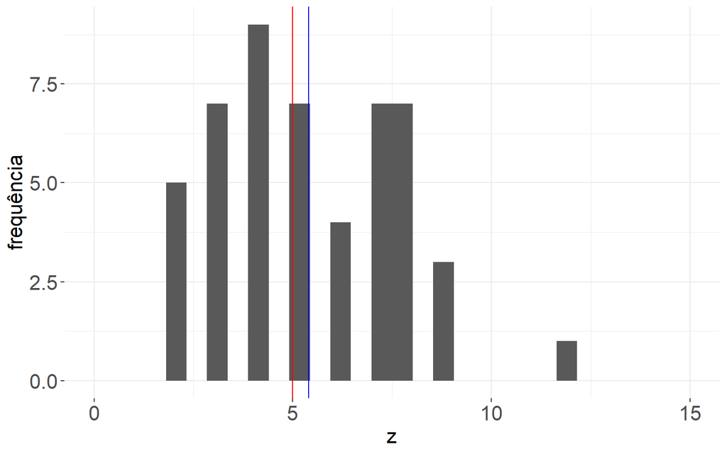

```r
# Gerando uma amostra de tamanho 50 e plotando os dados gerados
amostra.p = rpois(50, lambda = 5)

ggplot(mapping = aes(x = amostra.p)) +
  geom_histogram() +
  geom_vline(xintercept = 5, col = "red") +
  geom_vline(xintercept = mean(amostra.p), col = "blue") +
  labs(y = "frequência", x = "z") +
  xlim(0,15) +
  theme_bw() +
  theme(axis.text.x = element_text(size = 16),
        axis.title.x = element_text(size = 16),
        axis.text.y = element_text(size = 16),
        axis.title.y = element_text(size = 16),
        panel.border = element_blank())
```

#### Distribuição Exponencial

Seja $Y$ a variável aleatória com distribuição $Exponencial(\lambda)$, ou seja, tem-se que $Y \sim Exp(\lambda)$. Nos exemplos abaixo, considere $Y \sim Exp(2)$:

```r
# Calculando f(1), função de densidade no ponto 1
dexp(1, rate = 2)
```

```
[1] 0.2706706
```

```r
# Calculando P(Y<0.5)
pexp(0.5, rate = 2)
```

```
[1] 0.6321206
```

```r
# Calculando P(Y>=1)
1-pexp(1, rate = 2)
```

```
[1] 0.1353353
```

```r
# Calculando P(0.2<Y<0.5)
pexp(0.5, rate = 2) - pexp(0.2, rate = 2)
```

```
[1] 0.3024406
```

```r
# Calculando o percentil 95
qexp(0.95, rate = 2)
```

```
[1] 1.497866
```

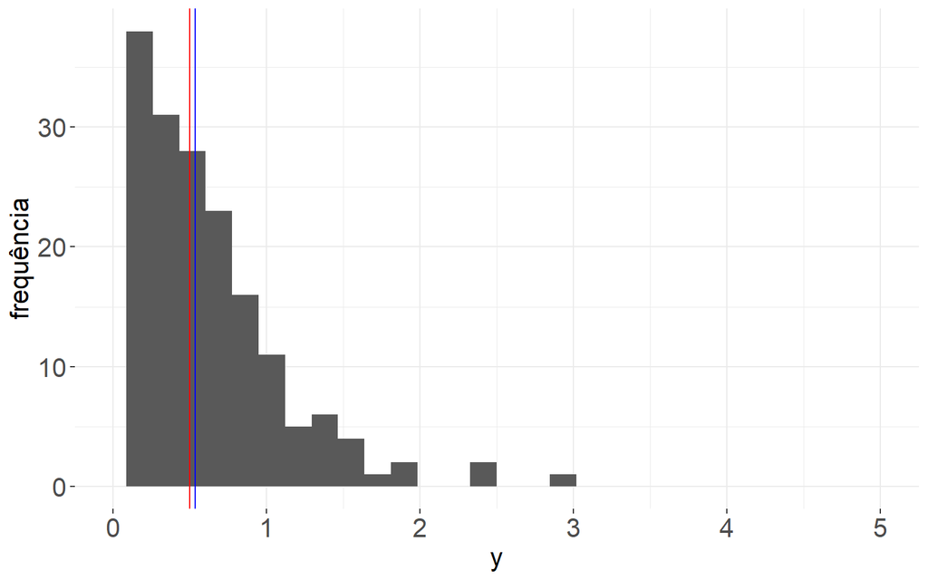

```r
# Gerando uma amostra de tamanho 200 e plotando os dados gerados
amostra.e = rexp(200, rate = 2)

ggplot(mapping = aes(x = amostra.e)) +
  geom_histogram() +
  geom_vline(xintercept = 1/2, col = "red") +
  geom_vline(xintercept = mean(amostra.e), col = "blue") +
  labs(y = "frequência", x = "y") +
  xlim(0,5) +
  theme_bw() +
  theme(axis.text.x = element_text(size = 16),
        axis.title.x = element_text(size = 16),
        axis.text.y = element_text(size = 16),
        axis.title.y = element_text(size = 16),
        panel.border = element_blank())
```